# regtools

Norm Matloff

# regtools

## Novel tools tools for linear, nonlinear and nonparametric regression.

These tools are associated with my forthcoming book, *From Linear Models to Machine Learning: Modern Statistical Regression and Classification*, N. Matloff, CRC, 2017.

*The tools are useful in general, independently of the book*.

## FEATURES:

- Nonparametric regression for general dimensions in predictor and response variables, using k-Nearest Neighbors. Local-linear option. Allows for user-specified smoothing method. Allows for accelerated exploration of multiple values of *k* at once. Tool to aid in choosing *k*.
- Innovative tools for assessing fit in linear and nonlinear parametric models, via nonparametric methods. Model evaluation, examination of quadratic effects, investigation of nonhomogeneity of variance.
- Tools for multiclass classification, parametric and nonparametric. One vs. All and All vs. All. Novel adjustment for artificially balanced data.
- Linear regression, PCA and log-linear model estimation in missing-data setting, via the Available Cases method.
- Nicer implementation of ridge regression, with more meaningful scaling and better plotting.
- Extension to nonlinear parametric regression with of Eickert-White technique to handle heteroscedasticity.
- Misc. tools, e.g. Method of Moments estimation (including for nonregression settings).

## EXAMPLE: MODEL FIT ASSESSMENT

Let’s take a look at the data set **prgeng**, some Census data for California engineers and programmers in the year 2000. The response variable in this example is wage income, and the predictors are age, number of weeks worked, and dummy variables for MS and PhD degrees. (Some data wrangling was performed first; type **?knnest** for the details.)

The fit assessment techniques in **regtools** gauge the fit of parametric models by comparing to nonparametric ones. Since the latter are free of model bias, they are very useful in assessing the parametric models.

The function **nonparvsxplot()** plots the nonparametric fits against each predictor variable, for instance to explore nonlinear effects. Here is the plot for wage versus (scaled) age:

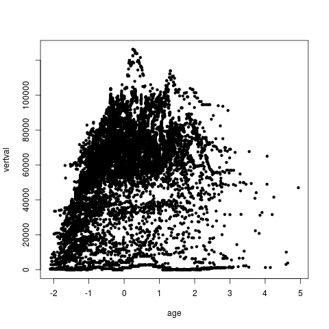

Of course, the effects of the other predictors don’t show up here, but there does seem to be a quadratic effect. The same was true for the predictor measuring the number of weeks worked (slightly concave up, not shown here). In our linear parametric model, then, we will include squared terms for these two predictors.

So, after fitting the linear model, run **parvsnonparplot()**, which plots the fit of the parametric model against the nonparametric one. Here is the result:

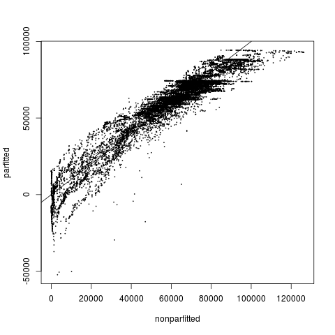

There is quite a bit suggested in this picture:

- There seems to be some overfitting near the low end, and underfitting at the high end.
- The outliers, meaning points far from the fitted linear model, are almost all below the linear fit.
- There are intriguing “sreaks” or “tails” of points, suggesting the possible existence of important subpopulations.
- There appear to be a number of people with 0 wage income. Depending on the goals of our analysis, we might consider removing them.

Finally, let’s check the classical assumption of homoscedasticity, meaning that the conditional variance of Y given X is constant. The function **nonparvarplot()** plots the estimated conditional variance against the estimated conditional mean, both computed nonparametrically::

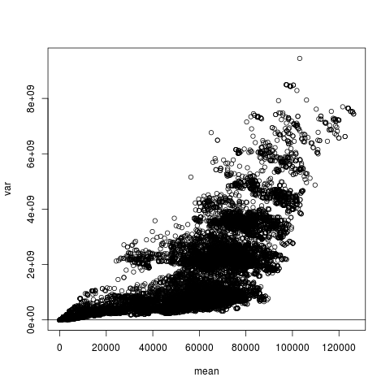

What to do? As long as our linear regression model assumption holds, violation of the homoscedasticity assumption won’t invalidate our estimates; they still will be *statistically consistent*. But the standard errors we compute, and thus the statistical inference we perform, will be affected. This is correctible using the Eickert-White procedure, which for linear models is available in the **car** package, included in **regtools**. Our package also extends this to nonlinear parametric models, in our function **nlshc()** (the validity of this extension is shown in the book).

Of course, the “hockey stick” form is another indication that we should further investigate the model itself. It may well be useful to fit two separate linear models, one for incomes below $80K and the other for the higher incomes. For a more formal approach to this, we might consider *changepoint* methods, such as in the CRAN package **chngpt**.

**What is different:**

Note carefully that the above graph is unaffected by the validity of the parametric model; it is based purely on nonparametric analysis. This is in contrast to classic regression fit methods, most of which are based on examination of residuals of the fitted model.

## EXAMPLE: OVA VS. AVA IN MULTICLASS PROBLEMS

A very popular prediction method in 2-class problems is to use logistic (logit) regression. In analyzing click-through patterns of Web users, for instance, we have 2 classes, Click and Nonclick. We might fit a logistic model for Click, given user Web history, demographics and so on. Note that logit actually models probabilities, e.g. the probability of Click given the predictor variables.

At any rate, the **regtools** package gives you a choice, OVA or AVA, for both parametric and nonparametric methods. For example, **avalogtrn()** and **avalogpred()** do training and prediction operations for logit with AVA.

Another feature concerns adjustment of class probabilities. In many multiclass data sets, the numbers of points in each class is the same, or least not reflective of the population class probabilities. In **regtools**, the user can specify estimates of the latter, for logit and nonparametric methods.

So, let’s look at an example, using the UCI Letter Recognition data set, another image recognition example. Again, the code below was preceded by some data wrangling, which changed the letter data from character to numeric, and which divided the data set into training and test sets. Here is the OVA run:

```
> ologout <- ovalogtrn(26,lrtrn[,c(2:17,1)])
> ypred <- ovalogpred(ologout,lrtest[,-1])
> mean(ypred == lrtest[,1])
[1] 0.7193333
```

So, we get about a 72% rate of correct classification. Now let’s try AVA:

```
> alogout <- avalogtrn(26,lrtrn[,c(2:17,1)])
> ypred <- avalogpred(26,alogout,lrtest[,-1])
> mean(ypred == lrtest[,1])
[1] 0.8355
```

There were 16 predictors, thus 16 possible quadratic terms, and C(16,2) = 120 possible interaction terms. Inclusion of all such variables would probably produce too rich a model for the 14000 points in our training set. We’ll settle for adding just the squared terms (not shown):

```
> ologout <- ovalogtrn(26,lrtrn[,c(2:33,1)])
> ypred <- ovalogpred(ologout,lrtest[,-1])
> mean(ypred == lrtest[,1])
[1] 0.8086667
```

Ah, much better, though still not quite as good as AVA.